# Meta-analysis 1

Shari Liu

3/24/2021

```r
ind.data.pre <- read.csv("./individual_data.csv") %>%
  mutate(experiment=str_sub(condition,1,1)) %>%
  mutate_if(is.character,as.factor) %>%
  mutate(subj = as.factor(subj))


ma.data <- read.csv("./ma_data.csv") %>%
  rename(paper = study_ID,
         condition = expt_condition,
         experiment = expt_num,
         task = looking_task) %>%
    mutate_if(is.character,as.factor)


study.design <- ma.data %>%
  select(paper, experiment, condition, task, training_yesno, action_consequence, actor_hand, agent_efficient_fam, object_diff_size_huge, action_causal, action_consequence, location_object_goal_ambiguous, bothobjects_present_visible_fam, agent, PI_group) %>%
    mutate_if(is.character,as.factor) %>%
  mutate(experiment = as.factor(experiment)) %>%
  filter(paper != "sommerville2005",
         task != "causes")


# merge study design with individual looks from babies

ind.data <- left_join(ind.data.pre, study.design,
                      by=c("paper", "experiment", "condition")) %>%
  mutate(sex = tolower(str_sub(sex,1,1)),
         look_pref = unexp_look - exp_look) %>%
  mutate_if(is.character,as.factor)
str(ind.data)
```

```
# 'data.frame': 626 obs. of  20 variables:
#  $ subj                           : Factor w/ 626 levels "1","2","3","4",..: 1 2 3 4 5 6 7 8 9 10 ...
#  $ condition                      : Factor w/ 35 levels "1_Active","1_Control",..: 12 12 12 12 12 12 12 12 12 12 ...
#  $ ageday                         : num  103.3 86.9 105.3 129.8 107.3 ...
#  $ exp_look                       : num  13.1 18.4 15.1 7.1 5.8 9 18.9 6 31 42.9 ...
#  $ unexp_look                     : num  60 60 46.3 13.6 12 60 8 21 60 42.7 ...
#  $ sex                            : Factor w/ 2 levels "f","m": 2 2 2 1 1 1 2 2 2 1 ...
#  $ paper                          : Factor w/ 11 levels "choi_unpublished",..: 6 6 6 6 6 6 6 6 6 6 ...
#  $ experiment                     : Factor w/ 6 levels "1","2","3","4",..: 1 1 1 1 1 1 1 1 1 1 ...
#  $ task                           : Factor w/ 3 levels "causes","efficiency",..: 3 3 3 3 3 3 3 3 3 3 ...
#  $ training_yesno                 : Factor w/ 2 levels "no","yes": 1 1 1 1 1 1 1 1 1 1 ...
#  $ action_consequence             : Factor w/ 3 levels "location_change",..: 2 2 2 2 2 2 2 2 2 2 ...
#  $ actor_hand                     : Factor w/ 3 levels "bare","gloved",..: NA NA NA NA NA NA NA NA NA NA ...
#  $ agent_efficient_fam            : Factor w/ 2 levels "no","yes": NA NA NA NA NA NA NA NA NA NA ...
#  $ object_diff_size_huge          : Factor w/ 2 levels "no","yes": 1 1 1 1 1 1 1 1 1 1 ...
#  $ action_causal                  : Factor w/ 2 levels "no","yes": 1 1 1 1 1 1 1 1 1 1 ...
#  $ location_object_goal_ambiguous : Factor w/ 2 levels "no","yes": 2 2 2 2 2 2 2 2 2 2 ...
#  $ bothobjects_present_visible_fam: Factor w/ 3 levels "","no","yes": 3 3 3 3 3 3 3 3 3 3 ...
#  $ agent                          : Factor w/ 3 levels "hand","object",..: 2 2 2 2 2 2 2 2 2 2 ...
#  $ PI_group                       : Factor w/ 5 levels "desrochers","luo",..: 2 2 2 2 2 2 2 2 2 2 ...
#  $ look_pref                      : num  46.9 41.6 31.2 6.5 6.2 ...
```

```r
# View(ind.data)
```

```r
# function that returns column of standardized betas from lmer model
gen.beta <- function(model) {
    df <- data.frame(fixef(model))
    names(df) <- c("beta")
    return(df)
}
# function that computes CIs and returns them in df
gen.ci <- function(model) {
  df <- data.frame(confint(model))
  names(df) <- c("lower", "upper")
  return(df)
}
# function that converts model summary (lmer) to df
gen.m <- function(model) {
  df <- data.frame(coef(summary(model)))
  names(df) <- c("b", "se", "df", "t", "p")
  return(df)
}
# function that converts model summary (lm) to df
gen.lm <- function(model) {
  df <- data.frame(coef(summary(model)))
  names(df) <- c("b", "se", "t", "p")
  return(df)
}
# function that returns age info and number of females in a dataset
ages <- function(longdata) {
  longdata %>% summarize(mean = mean(ageday), min=range(ageday)[1], max=range(ageday)[2], f=sum(sex=="f")/2)
}
# function that returns formatted result from lme4/lmerTest table
report <- function(table, index, places, tails, flip) {
  if (tails == "1") {
    p <- round(table$p[index], places)/2
    howmanytails <- "one-tailed"
  } else {
    p <- round(table$p[index], places)
    howmanytails <- "two-tailed"
  }
  if (p < .001) {
    p <- "<.001"
  } else {
    p <- paste("=", round(p, places), sep = "")
  }
  if (missing(flip)) {
    result <- paste("[", round(table$lower[index], places), ",", round(table$upper[index], places), "], ß=", round(table$beta[index], places), ", B=", round(table$b[index],places), ", SE=", round(table$se[index],places), ", p", p, ", ", howmanytails, sep = "")
  } else {
    result <- paste("[", -round(table$upper[index], places), ",", -round(table$lower[index], places), "], ß=", -round(table$beta[index], places), ", B=", -round(table$b[index],places), ", SE=", round(table$se[index],places), ", p", p, ", ", howmanytails, sep = "")
  }
  return(result)
}

describe <- function(dataset){
  summary <- dataset %>%
  summarise(unexp_avg = mean(unexp_look),
            exp_avg = mean(exp_look),
            lookdiff_avg = mean(look_pref),
            n = n())
  paste(
        #"M_unexp = ", summary$unexp_avg, "s ",
        #"M_exp = ", summary$exp_avg, "s ",
        "Mean_diff = ", round(summary$lookdiff_avg,3), "seconds"
  )
}
```

```r
## Retrieved from : http://www.cookbook-r.com/Graphs/Plotting_means_and_error_bars_(ggplot2)/#error-bars-for-within-subjects-variables
## Gives count, mean, standard deviation, standard error of the mean, and confidence interval (default 95%).
##   data: a data frame.
##   measurevar: the name of a column that contains the variable to be summariezed
##   groupvars: a vector containing names of columns that contain grouping variables
##   na.rm: a boolean that indicates whether to ignore NA's
##   conf.interval: the percent range of the confidence interval (default is 95%)
summarySE <- function(data=NULL, measurevar, groupvars=NULL, na.rm=FALSE,
                      conf.interval=.95, .drop=TRUE) {
  library(plyr)

  # New version of length which can handle NA's: if na.rm==T, don't count them
  length2 <- function (x, na.rm=FALSE) {
    if (na.rm) sum(!is.na(x))
    else       length(x)
  }

  # This does the summary. For each group's data frame, return a vector with
  # N, mean, and sd
  datac <- ddply(data, groupvars, .drop=.drop,
                 .fun = function(xx, col) {
                   c(N    = length2(xx[[col]], na.rm=na.rm),
                     mean = mean   (xx[[col]], na.rm=na.rm),
                     sd   = sd     (xx[[col]], na.rm=na.rm)
                   )
                 },
                 measurevar
  )

  # Rename the "mean" column
  datac <- plyr::rename(datac, c("mean" = measurevar))

  datac$se <- datac$sd / sqrt(datac$N)  # Calculate standard error of the mean

  # Confidence interval multiplier for standard error
  # Calculate t-statistic for confidence interval:
  # e.g., if conf.interval is .95, use .975 (above/below), and use df=N-1
  ciMult <- qt(conf.interval/2 + .5, datac$N-1)
  datac$ci <- datac$se * ciMult

  return(datac)
}
## Norms the data within specified groups in a data frame; it normalizes each
## subject (identified by idvar) so that they have the same mean, within each group
## specified by betweenvars.
##   data: a data frame.
##   idvar: the name of a column that identifies each subject (or matched subjects)
##   measurevar: the name of a column that contains the variable to be summariezed
##   betweenvars: a vector containing names of columns that are between-subjects variables
##   na.rm: a boolean that indicates whether to ignore NA's
normDataWithin <- function(data=NULL, idvar, measurevar, betweenvars=NULL,
                           na.rm=FALSE, .drop=TRUE) {
  library(plyr)

  # Measure var on left, idvar + between vars on right of formula.
  data.subjMean <- ddply(data, c(idvar, betweenvars), .drop=.drop,
                         .fun = function(xx, col, na.rm) {
                           c(subjMean = mean(xx[,col], na.rm=na.rm))
                         },
                         measurevar,
                         na.rm
  )

  # Put the subject means with original data
  data <- merge(data, data.subjMean)

  # Get the normalized data in a new column
  measureNormedVar <- paste(measurevar, "_norm", sep="")
  data[,measureNormedVar] <- data[,measurevar] - data[,"subjMean"] +
    mean(data[,measurevar], na.rm=na.rm)

  # Remove this subject mean column
  data$subjMean <- NULL

  return(data)
}

## Summarizes data, handling within-subjects variables by removing inter-subject variability.
## It will still work if there are no within-S variables.
## Gives count, un-normed mean, normed mean (with same between-group mean),
##   standard deviation, standard error of the mean, and confidence interval.
## If there are within-subject variables, calculate adjusted values using method from Morey (2008).
##   data: a data frame.
##   measurevar: the name of a column that contains the variable to be summariezed
##   betweenvars: a vector containing names of columns that are between-subjects variables
##   withinvars: a vector containing names of columns that are within-subjects variables
##   idvar: the name of a column that identifies each subject (or matched subjects)
##   na.rm: a boolean that indicates whether to ignore NA's
##   conf.interval: the percent range of the confidence interval (default is 95%)
summarySEwithin <- function(data=NULL, measurevar, betweenvars=NULL, withinvars=NULL,
                            idvar=NULL, na.rm=FALSE, conf.interval=.95, .drop=TRUE) {

  # Ensure that the betweenvars and withinvars are factors
  factorvars <- vapply(data[, c(betweenvars, withinvars), drop=FALSE],
                       FUN=is.factor, FUN.VALUE=logical(1))

  if (!all(factorvars)) {
    nonfactorvars <- names(factorvars)[!factorvars]
    message("Automatically converting the following non-factors to factors: ",
            paste(nonfactorvars, collapse = ", "))
    data[nonfactorvars] <- lapply(data[nonfactorvars], factor)
  }

  # Get the means from the un-normed data
  datac <- summarySE(data, measurevar, groupvars=c(betweenvars, withinvars),
                     na.rm=na.rm, conf.interval=conf.interval, .drop=.drop)

  # Drop all the unused columns (these will be calculated with normed data)
  datac$sd <- NULL
  datac$se <- NULL
  datac$ci <- NULL

  # Norm each subject's data
  ndata <- normDataWithin(data, idvar, measurevar, betweenvars, na.rm, .drop=.drop)

  # This is the name of the new column
  measurevar_n <- paste(measurevar, "_norm", sep="")

  # Collapse the normed data - now we can treat between and within vars the same
  ndatac <- summarySE(ndata, measurevar_n, groupvars=c(betweenvars, withinvars),
                      na.rm=na.rm, conf.interval=conf.interval, .drop=.drop)

  # Apply correction from Morey (2008) to the standard error and confidence interval
  #  Get the product of the number of conditions of within-S variables
  nWithinGroups    <- prod(vapply(ndatac[,withinvars, drop=FALSE], FUN=nlevels,
                                  FUN.VALUE=numeric(1)))
  correctionFactor <- sqrt( nWithinGroups / (nWithinGroups-1) )

  # Apply the correction factor
  ndatac$sd <- ndatac$sd * correctionFactor
  ndatac$se <- ndatac$se * correctionFactor
  ndatac$ci <- ndatac$ci * correctionFactor

  # Combine the un-normed means with the normed results
  merge(datac, ndatac)
}
```

```r
ind.data.long <- ind.data %>%
         rename(expected = exp_look,
                unexpected = unexp_look) %>%
         pivot_longer(cols = c(expected, unexpected),
                      names_to = "trial_type",
                      values_to = "looking_time")

ind.data.summary <- summarySEwithin(data = ind.data.long, measurevar = "looking_time", betweenvars = c("task", "paper", "experiment", "condition"), withinvars = "trial_type")
```

```
# Automatically converting the following non-factors to factors: trial_type
```

# Plots

```r
plot1 <- ggplot(ind.data.long,
       aes(trial_type, looking_time, colour=paper))+
  theme_cowplot(12)+
  theme(legend.title = element_blank())+
  geom_boxplot(outlier.alpha = 0.2)+
  geom_point(alpha=0.2)+
  geom_line(aes(group=subj), alpha=0.2)+
  stat_summary(geom="point", fun="mean", colour="black")+
  # geom_errorbar(data = ind.data.summary, colour="red", position = position_dodge(width = 5), width = 0, aes(ymin=looking_time-se, ymax=looking_time+se)) +
  stat_summary(geom="errorbar", fun.data="mean_se", width=0.2, colour="black")+
  ylab("Looking Time (s)")+
  facet_grid(~task+paper+condition, labeller=label_wrap_gen())+
  theme(axis.text.x = element_text(angle = 90, hjust=0.95, vjust =0.2))
```

[figure not shown]

```r
plot2 <- ggplot(ind.data,
                 aes(condition, look_pref, colour=paper)) +
  geom_boxplot(outlier.alpha = 0.2, position = position_dodge2(preserve = "single"))+
  geom_hline(yintercept = 0)+
  geom_point(alpha=0.2)+
  stat_summary(geom="point", fun="mean", colour="black")+
  stat_summary(geom="errorbar", fun.data="mean_se", width=0.2, colour="black")+
  theme_cowplot(12)+
  facet_grid(~task+paper,scales = "free_x",space = "free")+
  ylab("Looking preference (s) \n <- Expected ------- Unexpected ->")+
  theme(axis.text.x = element_text(angle = 90, hjust=0.95, vjust =0.2))

plot2
```

[output not shown]

[figure not shown]

```r
(plot3 <- ggplot(ind.data,
                 aes(ageday, look_pref, colour=paper)) +
  # geom_boxplot(outlier.alpha = 0.2, position = position_dodge2(preserve = "single"))+
  geom_hline(yintercept = 0)+
  geom_point()+
  geom_smooth(method="lm")+
  # stat_summary(geom="point", fun="mean", colour="black")+
  # stat_summary(geom="errorbar", fun.data="mean_se", width=0.2, colour="black")+
  theme_cowplot(12)+
  facet_grid(~task+paper)+
  ylab("Looking preference (s) \n <- Expected ------- Unexpected ->")+
  theme(axis.text.x = element_text(angle = 90, hjust=0.95, vjust =0.2)))
```

## Constraints Task

### Baseline Effect

```r
constraints <- ind.data %>% filter(task =="efficiency")
constraints.baseline.data <- constraints %>%
  filter(condition %in% c("3_notraining",
                          "1_pickupglove",
                          "2_pickupbarehand"))

constraints.b1 <- lmer(data = constraints.baseline.data,
                       formula = look_pref ~ 1 + ageday + (1|condition))
summary(constraints.b1)
```

```
# Linear mixed model fit by REML. t-tests use Satterthwaite's method [
# lmerModLmerTest]
# Formula: look_pref ~ 1 + ageday + (1 | condition)
#    Data: constraints.baseline.data
#
# REML criterion at convergence: 366.4
#
# Scaled residuals:
#     Min      1Q  Median      3Q     Max
# -2.7189 -0.5297 -0.0435  0.7252  2.2686
#
# Random effects:
#  Groups    Name        Variance Std.Dev.
#  condition (Intercept)  2.03    1.42
#  Residual              25.37    5.04
# Number of obs: 60, groups:  condition, 3
#
# Fixed effects:
#             Estimate Std. Error      df t value Pr(>|t|)
# (Intercept)  -2.3930     9.0407 57.2416   -0.26     0.79
# ageday        0.0258     0.0832 56.0050    0.31     0.76
#
# Correlation of Fixed Effects:
#        (Intr)
# ageday -0.993
```

```r
constraints.b1.table <- sjPlot:: tab_model(constraints.b1,
                                           show.std =TRUE,
                                           show.stat=TRUE,
                                           show.df=TRUE)

constraints.b1.beta <- summary(effectsize::standardize(constraints.b1))

constraints.baseline <- cbind(
  gen.beta(effectsize::standardize(constraints.b1)),
  gen.m(constraints.b1),
  gen.ci(constraints.b1)[3:4,]
)
```

```
# Computing profile confidence intervals ...
```

```r
constraints.baseline
```

```
#                                beta        b      se    df       t      p
# (Intercept) -0.00000000000000002645 -2.39296 9.04071 57.24 -0.2647 0.7922
# ageday       0.03966247939082377660  0.02582 0.08316 56.01  0.3105 0.7574
#                lower   upper
# (Intercept) -20.1694 15.4724
# ageday       -0.1389  0.1897
```

```r
cooks1 <- cooks.distance(constraints.b1, group = "subj")
```

```
# Warning in cooks.distance.lmerMod(constraints.b1, group = "subj"): group is not
# a valid argument for this function. As of version 0.4.0, group has been replaced
# by level.
```

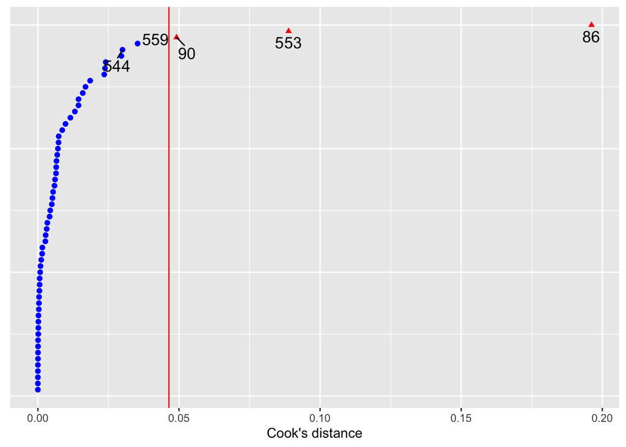

```r
dotplot_diag(x = cooks1, cutoff = "internal", name = "cooks.distance",  index=constraints.baseline.data$subj) + ylab("Cook's distance") + xlab("subjID")
```

```r
excluded.subs <- c("90", "553", "86")

constraints.b1.cooks <- lmer(data = constraints.baseline.data %>%
                         filter(!subj %in% excluded.subs),
                       formula = look_pref ~ 1 + ageday + (1|condition))

summary(constraints.b1.cooks)
```

```
# Linear mixed model fit by REML. t-tests use Satterthwaite's method [
# lmerModLmerTest]
# Formula: look_pref ~ 1 + ageday + (1 | condition)
#    Data: constraints.baseline.data %>% filter(!subj %in% excluded.subs)
#
# REML criterion at convergence: 338.6
#
# Scaled residuals:
#     Min      1Q  Median      3Q     Max
# -2.5544 -0.5380 -0.0717  0.7259  2.4971
#
# Random effects:
#  Groups    Name        Variance Std.Dev.
#  condition (Intercept)  1.14    1.07
#  Residual              21.61    4.65
# Number of obs: 57, groups:  condition, 3
#
# Fixed effects:
#             Estimate Std. Error      df t value Pr(>|t|)
# (Intercept)  -9.5734     9.0731 54.2948   -1.06     0.30
# ageday        0.0926     0.0838 53.5855    1.11     0.27
#
# Correlation of Fixed Effects:
#        (Intr)
# ageday -0.995
```

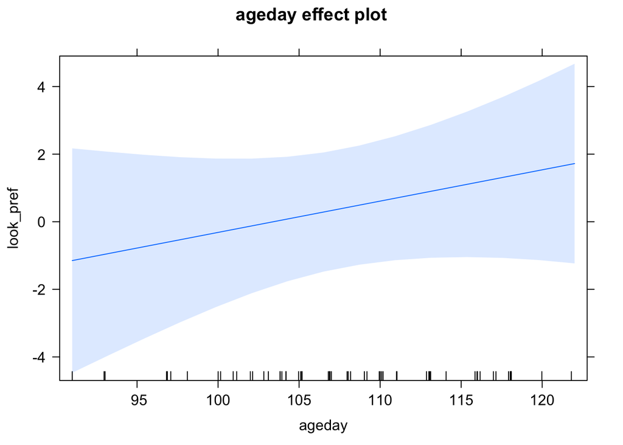

```r
plot(allEffects(constraints.b1.cooks))
```

```r
constraints.baseline.cooks <- cbind(
  gen.beta(effectsize::standardize(constraints.b1.cooks)),
  gen.m(constraints.b1.cooks),
  gen.ci(constraints.b1.cooks)[3:4,]
)
```

```
# Computing profile confidence intervals ...
```

For standard versions of the constraints task, we found no differential looking between the expected and unexpected events, Mean_diff = 0.395 seconds, [-0.139,0.19], ß=0.04, B=0.026, SE=0.083, p=0.757, two-tailed. This result held when we removed 3 influential observations, identified using Cook’s distance, [-0.07,0.263], ß=0.145, B=0.093, SE=0.084, p=0.274, two-tailed.

### Intervention Analysis

```r
constraints.m1 <- lmer(data = constraints,
     formula = look_pref ~ training_yesno + action_causal + action_consequence + actor_hand + agent_efficient_fam + ageday + (1|condition) + (1|experiment) + (1|paper))
```

```
# boundary (singular) fit: see ?isSingular
```

```
# Warning in as_lmerModLT(model, devfun): Model may not have converged with 1
# eigenvalue close to zero: -3.1e-11
```

```r
summary(constraints.m1)
```

```
# Linear mixed model fit by REML. t-tests use Satterthwaite's method [
# lmerModLmerTest]
# Formula: look_pref ~ training_yesno + action_causal + action_consequence +
#     actor_hand + agent_efficient_fam + ageday + (1 | condition) +
#     (1 | experiment) + (1 | paper)
#    Data: constraints
#
# REML criterion at convergence: 1682
#
# Scaled residuals:
#    Min     1Q Median     3Q    Max
# -3.729 -0.510 -0.059  0.561  3.866
#
# Random effects:
#  Groups     Name        Variance Std.Dev.
#  condition  (Intercept)  0.000   0.000
#  experiment (Intercept)  0.000   0.000
#  paper      (Intercept)  0.121   0.347
#  Residual               35.324   5.943
# Number of obs: 264, groups:  condition, 12; experiment, 5; paper, 2
#
# Fixed effects:
#                      Estimate Std. Error       df t value Pr(>|t|)
# (Intercept)           -2.8929     4.6171 256.0000   -0.63  0.53151
# training_yesno1       -2.1859     0.6174 256.0000   -3.54  0.00047 ***
# action_causal1        -2.3185     0.5944 256.0000   -3.90  0.00012 ***
# action_consequence1   -1.0693     0.7763 256.0000   -1.38  0.16959
# actor_hand1            1.3018     1.0518 256.0000    1.24  0.21698
# actor_hand2            0.8084     1.0518 256.0000    0.77  0.44282
# agent_efficient_fam1  -1.7116     0.5377 256.0000   -3.18  0.00164 **
# ageday                 0.0231     0.0419 256.0000    0.55  0.58139
# ---
# Signif. codes:  0 '***' 0.001 '**' 0.01 '*' 0.05 '.' 0.1 ' ' 1
#
# Correlation of Fixed Effects:
#             (Intr) trnn_1 actn_cs1 actn_cn1 actr_1 actr_2 agn__1
# tranng_ysn1 -0.062
# action_csl1  0.143  0.085
# actn_cnsqn1  0.010  0.065  0.349
# actor_hand1  0.124 -0.227  0.001   -0.360
# actor_hand2 -0.060 -0.227  0.000    0.721   -0.597
# agnt_ffcn_1  0.092  0.314  0.275    0.210    0.000  0.000
# ageday      -0.982  0.017 -0.053   -0.036   -0.010 -0.008 -0.018
# convergence code: 0
# boundary (singular) fit: see ?isSingular
```

```
# `geom_smooth()` using formula 'y ~ x'
```

```
# `geom_smooth()` using formula 'y ~ x'
```

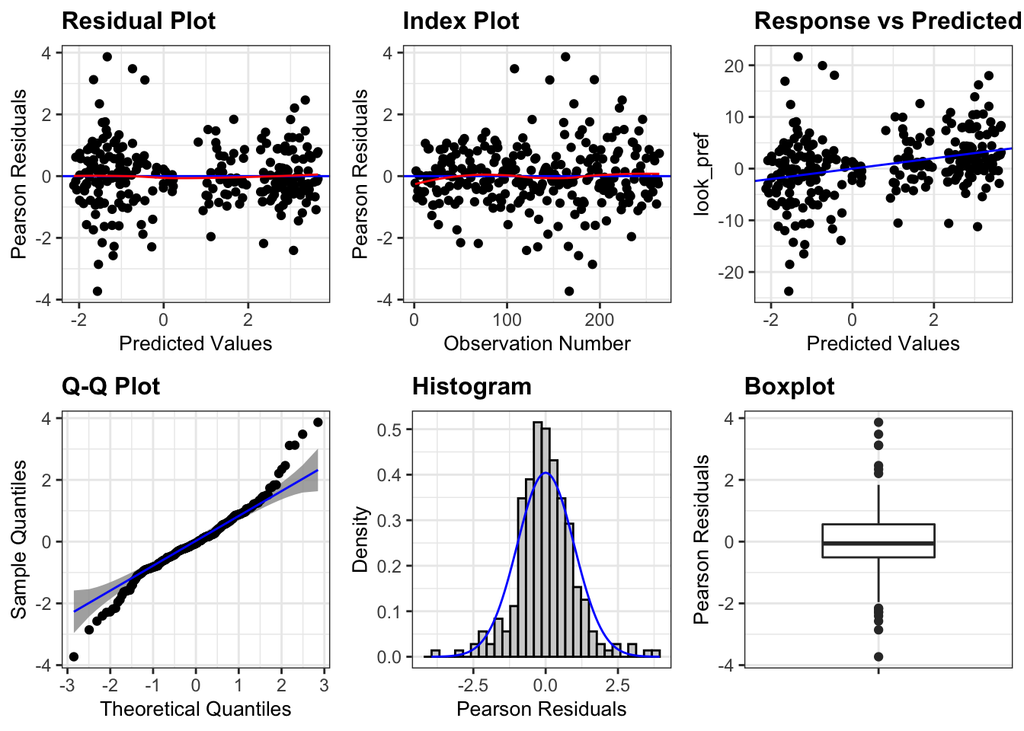

```r
resid_panel(constraints.m1, plots = "all",
                          smoother = TRUE,
                          qqbands = TRUE)
```

```r
cooks1 <- cooks.distance(constraints.m1, group = "subj")
```

```
# Warning in cooks.distance.lmerMod(constraints.m1, group = "subj"): group is not
# a valid argument for this function. As of version 0.4.0, group has been replaced
# by level.
```

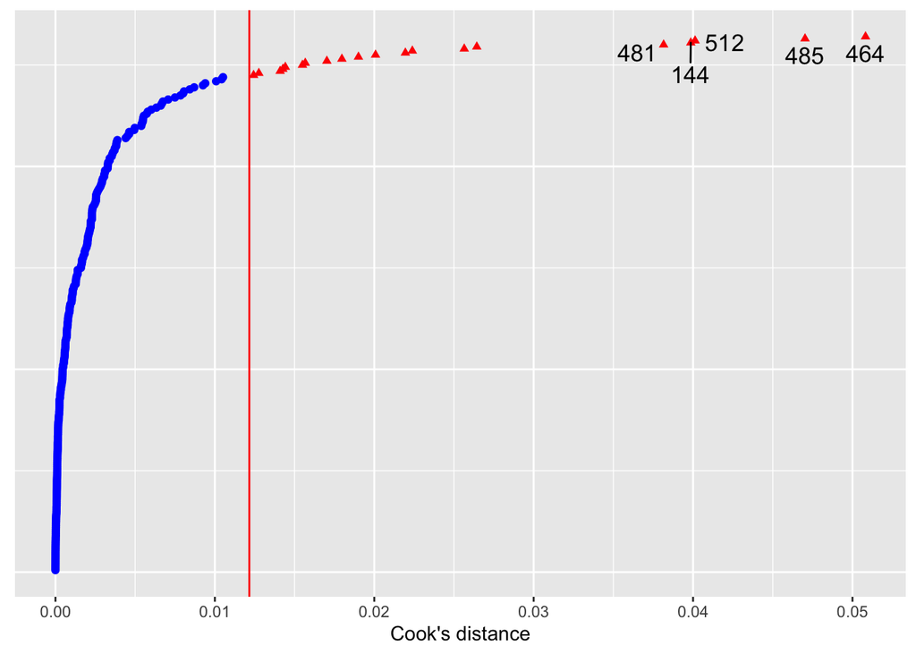

```r
dotplot_diag(x = cooks1, cutoff = "internal", name = "cooks.distance", index=constraints$subj) + ylab("Cook's distance") + xlab("ID")
```

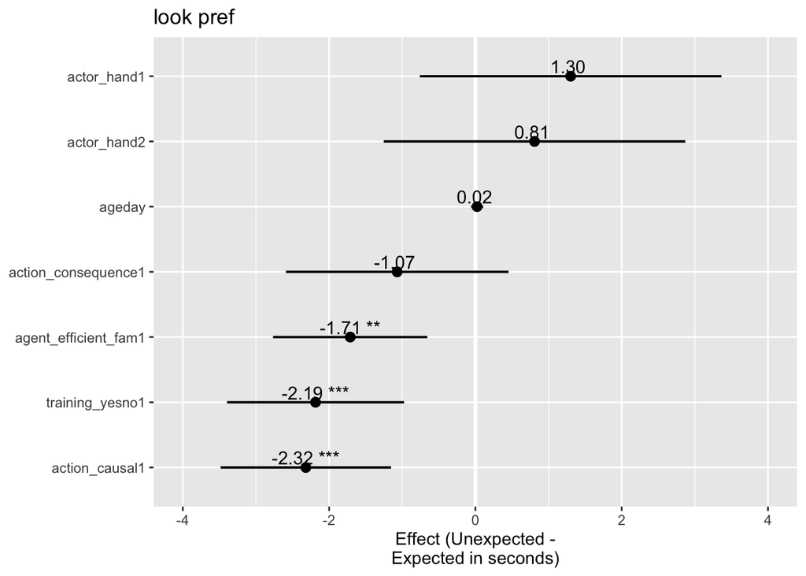

```r
sjPlot::plot_model(constraints.m1,
                   type = "est",
                   colors = "bw",
                   sort.est=TRUE,
                   axis.title=c("Effect (Unexpected - Expected in seconds)"),
                   show.values=TRUE,
                   show.p=TRUE)
```

```r
constraints.m1.table <- sjPlot:: tab_model(constraints.m1,
                                           show.std =TRUE,
                                           show.stat=TRUE,
                                           show.df=TRUE)
```

```
# boundary (singular) fit: see ?isSingular
```

```r
constraints.m1.beta <- summary(effectsize::standardize(constraints.m1))
```

```
# boundary (singular) fit: see ?isSingular
```

```r
constraints.interventions <- cbind(
  gen.beta(effectsize::standardize(constraints.m1)),
  gen.m(constraints.m1),
  gen.ci(constraints.m1)[3:10,]
)
```

```
# boundary (singular) fit: see ?isSingular
```

```
# Computing profile confidence intervals ...
```

```r
constraints.cooks<- constraints[which(cooks1 <= 4/264),]

constraints.m1.cooks <- lmer(data = constraints.cooks,
     formula = look_pref ~ training_yesno + action_causal + action_consequence + actor_hand + agent_efficient_fam + ageday + (1|condition) + (1|experiment) + (1|paper),
     REML=FALSE)
```

```
# boundary (singular) fit: see ?isSingular
```

```r
summary(constraints.m1.cooks)
```

```
# Linear mixed model fit by maximum likelihood . t-tests use Satterthwaite's
#   method [lmerModLmerTest]
# Formula: look_pref ~ training_yesno + action_causal + action_consequence +
#     actor_hand + agent_efficient_fam + ageday + (1 | condition) +
#     (1 | experiment) + (1 | paper)
#    Data: constraints.cooks
#
#      AIC      BIC   logLik deviance df.resid
#   1484.8   1527.0   -730.4   1460.8      237
#
# Scaled residuals:
#     Min      1Q  Median      3Q     Max
# -2.9748 -0.6479 -0.0429  0.6569  3.1180
#
# Random effects:
#  Groups     Name        Variance Std.Dev.
#  condition  (Intercept)  0.0     0.00
#  experiment (Intercept)  0.0     0.00
#  paper      (Intercept)  0.0     0.00
#  Residual               20.7     4.55
# Number of obs: 249, groups:  condition, 12; experiment, 5; paper, 2
#
# Fixed effects:
#                      Estimate Std. Error       df t value   Pr(>|t|)
# (Intercept)           -4.0078     3.6877 249.0000   -1.09      0.278
# training_yesno1       -1.9535     0.4773 249.0000   -4.09 0.00005773 ***
# action_causal1        -2.5634     0.4768 249.0000   -5.38 0.00000017 ***
# action_consequence1   -1.2255     0.6202 249.0000   -1.98      0.049 *
# actor_hand1            0.7581     0.8187 249.0000    0.93      0.355
# actor_hand2            0.9867     0.8311 249.0000    1.19      0.236
# agent_efficient_fam1  -1.9383     0.4261 249.0000   -4.55 0.00000844 ***
# ageday                 0.0281     0.0333 249.0000    0.84      0.400
# ---
# Signif. codes:  0 '***' 0.001 '**' 0.01 '*' 0.05 '.' 0.1 ' ' 1
#
# Correlation of Fixed Effects:
#             (Intr) trnn_1 actn_cs1 actn_cn1 actr_1 actr_2 agn__1
# tranng_ysn1 -0.061
# action_csl1  0.161  0.076
# actn_cnsqn1  0.007  0.058  0.330
# actor_hand1  0.120 -0.226  0.001   -0.377
# actor_hand2 -0.047 -0.223  0.002    0.744   -0.644
# agnt_ffcn_1  0.124  0.313  0.248    0.190    0.000  0.001
# ageday      -0.983  0.018 -0.070   -0.035   -0.009 -0.025 -0.050
# convergence code: 0
# boundary (singular) fit: see ?isSingular
```

```
# $training_yesno
```

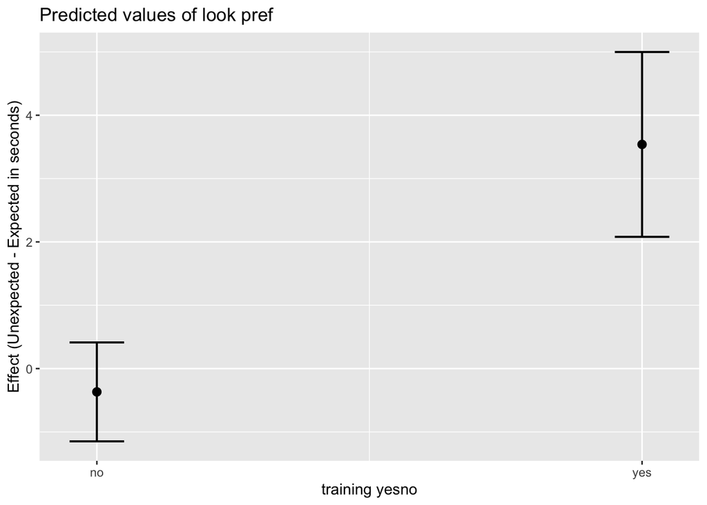

```
#
# $action_causal
```

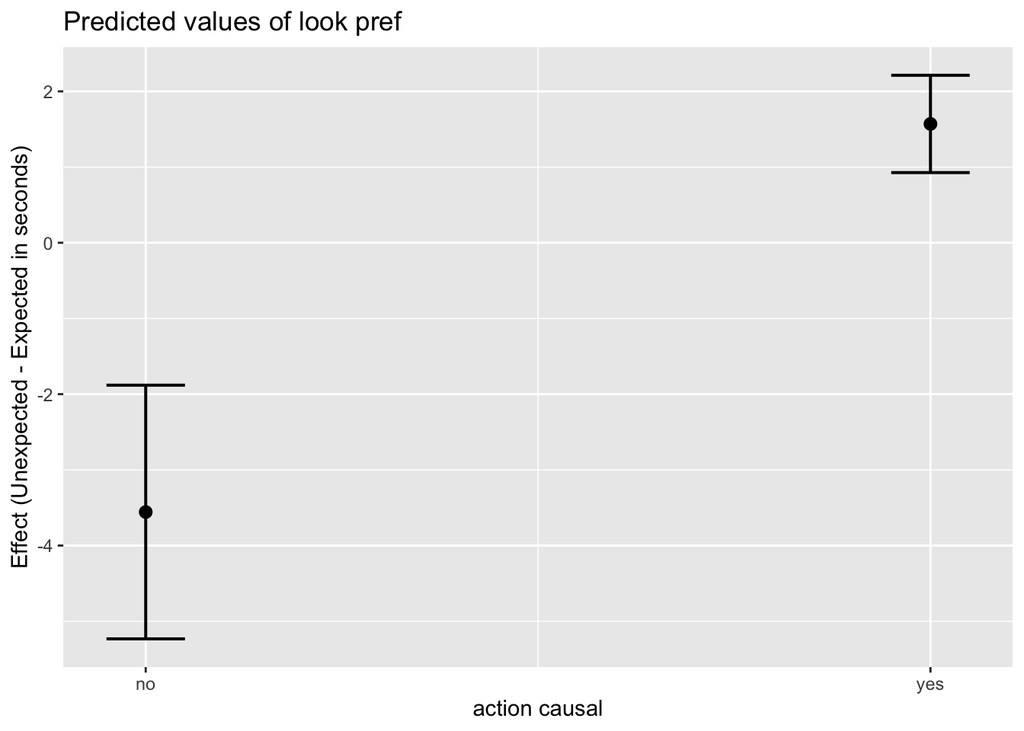

```
#
# $action_consequence
```

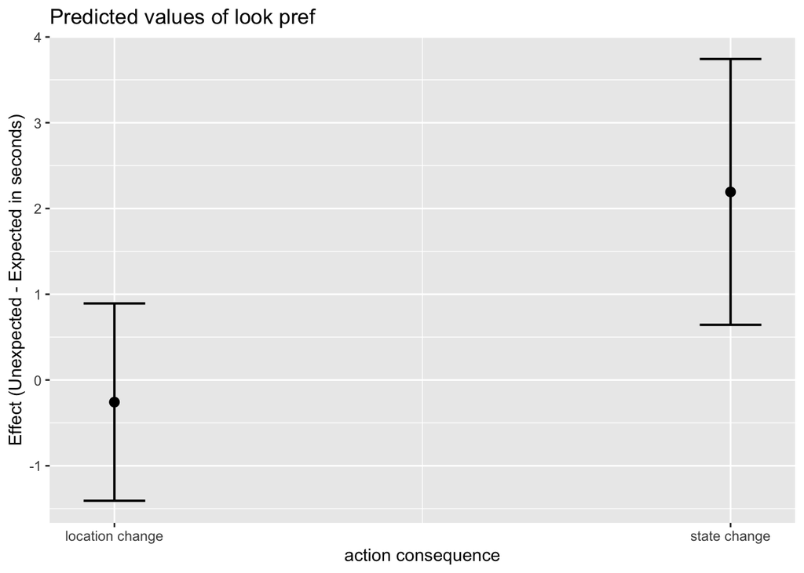

```
#
# $actor_hand
```

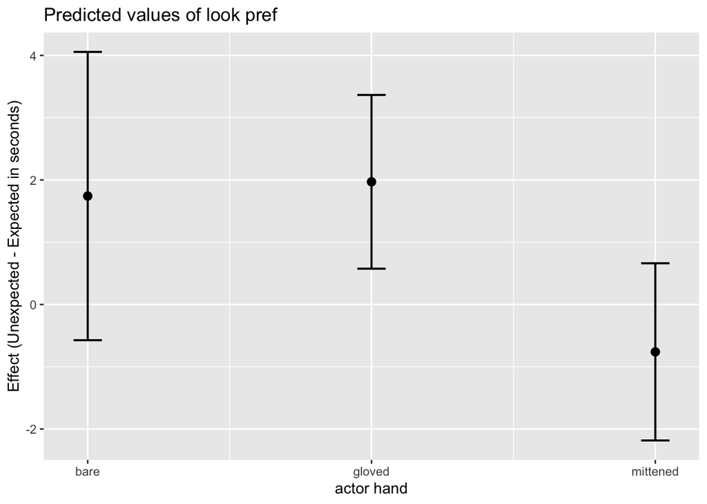

```
#
# $agent_efficient_fam
```

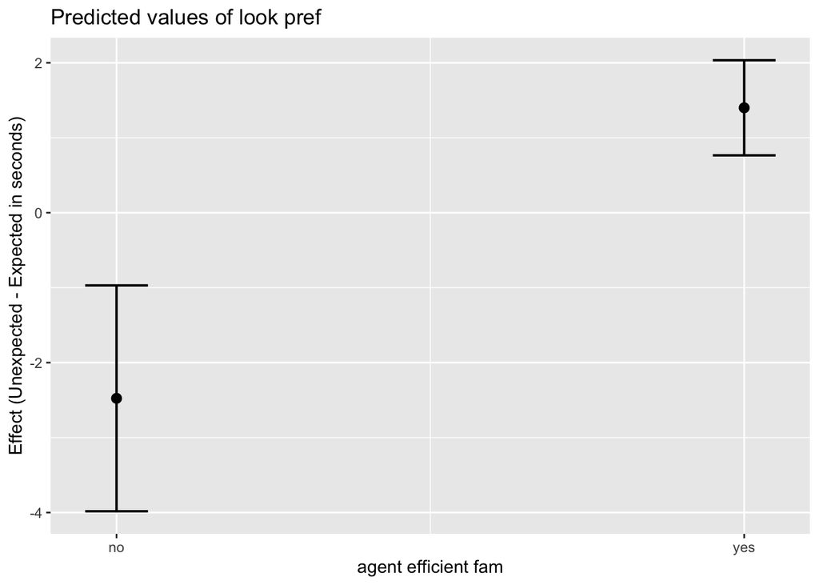

```
#
# $ageday
```

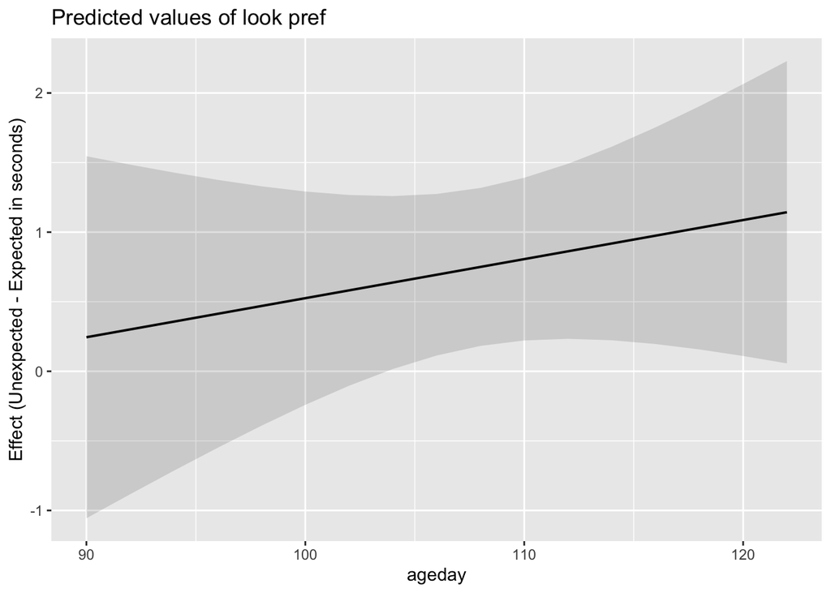

```r
sjPlot::plot_model(constraints.m1.cooks,
                   type = "eff",
                   # colors = "bw",
                   sort.est=TRUE,
                   axis.title=c("Effect (Unexpected - Expected in seconds)"),
                   show.values=TRUE,
                   show.p=TRUE)
```

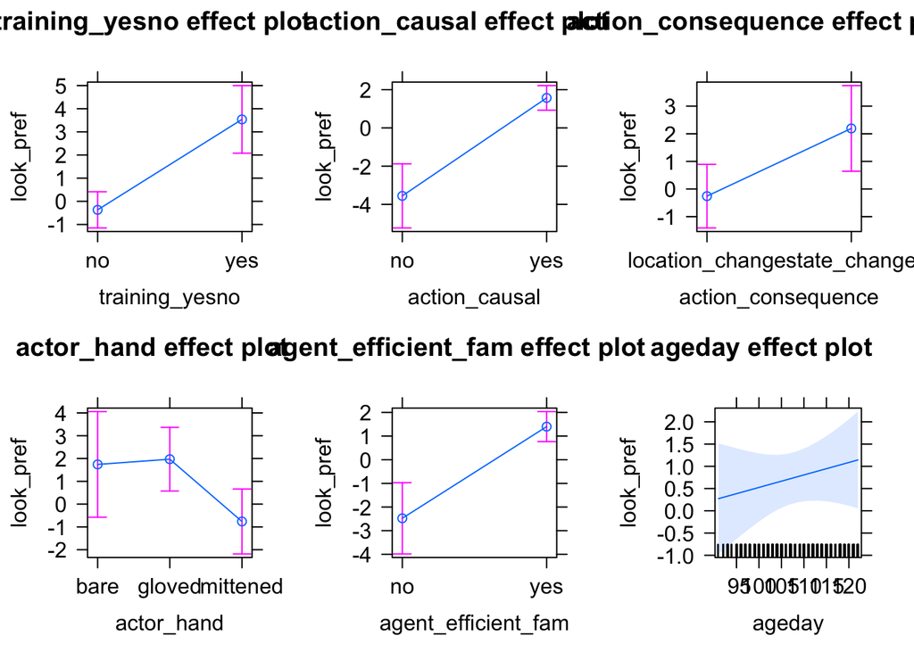

```r
plot(allEffects(constraints.m1.cooks))
```

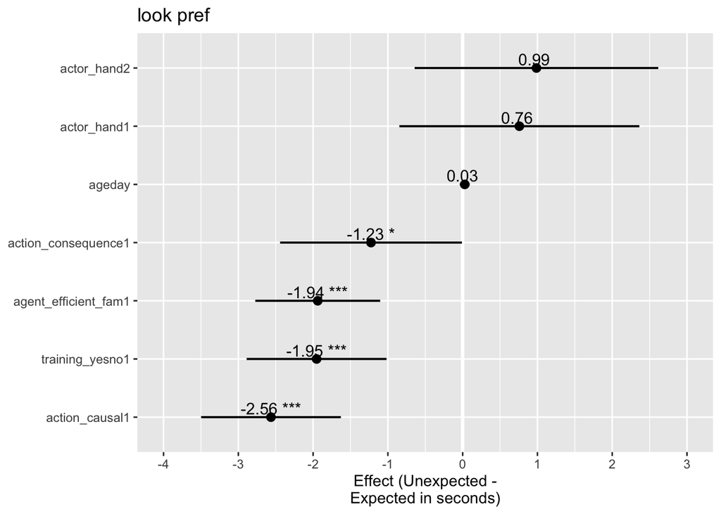

```r
sjPlot::plot_model(constraints.m1.cooks,
                   type = "est",
                   colors = "bw",
                   sort.est=TRUE,
                   axis.title=c("Effect (Unexpected - Expected in seconds)"),
                   show.values=TRUE,
                   show.p=TRUE)
```

```r
constraints.interventions.cooks <- cbind(
  gen.beta(effectsize::standardize(constraints.m1.cooks)),
  gen.m(constraints.m1.cooks),
  gen.ci(constraints.m1.cooks)[3:10,]
)
```

```
# boundary (singular) fit: see ?isSingular
# Computing profile confidence intervals ...
```

When we compared the effects of different variants we found that motor training robustly increased infants’ looking preference for the unexpected event ([4.175,4.978], ß=-0.391, B=-1.953, SE=0.477, p<.001, two-tailed). We also found that other interventions on the actions infants see, including seeing an action that causes an effect on contact ([-11.263,3.247], ß=-0.513, B=-2.563, SE=0.477, p<.001, two-tailed), and seeing a reaching action that results in an object changing state, rather than picking up that object ([-2.892,-1.014], ß=-0.245, B=-1.226, SE=0.62, p=0.049, two-tailed). These analyses included 249/264 total infants - the other 15 were classified as influential using Cook’s Distance. Including all subjects in the analysis produced similar results, except that the state change effect crossed the threshold into non-significance ([-3.382,-0.989], ß=-0.173, B=-1.069, SE=0.776, p=0.17, two-tailed). We did not find an effect of age, [-0.649,2.623], ß=0.049, B=0.028, SE=0.033, p=0.4, two-tailed.

## Goals Task

### Baseline Effect

```r
goals <- ind.data %>% filter(task =="goals")
goals.baseline.data <- goals %>%
  filter(condition %in% c("1_Control",
                          "1_twoobject") &
           paper %in% c("gerson2014a",
                        "luo2011"))

goals.b1 <- lmer(data = goals.baseline.data,
                       formula = look_pref ~ 1 + ageday + (1|condition))

goals.b1.table <- sjPlot:: tab_model(goals.b1,
                                           show.std =TRUE,
                                           show.stat=TRUE,
                                           show.df=TRUE)

goals.b1.beta <- summary(effectsize::standardize(goals.b1))

goals.baseline <- cbind(
  gen.beta(effectsize::standardize(goals.b1)),
  gen.m(goals.b1),
  gen.ci(goals.b1)[3:4,]
)
```

```
# Computing profile confidence intervals ...
```

```r
cooks1 <- cooks.distance(goals.b1, group = "subj")
```

```
# Warning in cooks.distance.lmerMod(goals.b1, group = "subj"): group is not a
# valid argument for this function. As of version 0.4.0, group has been replaced
# by level.
```

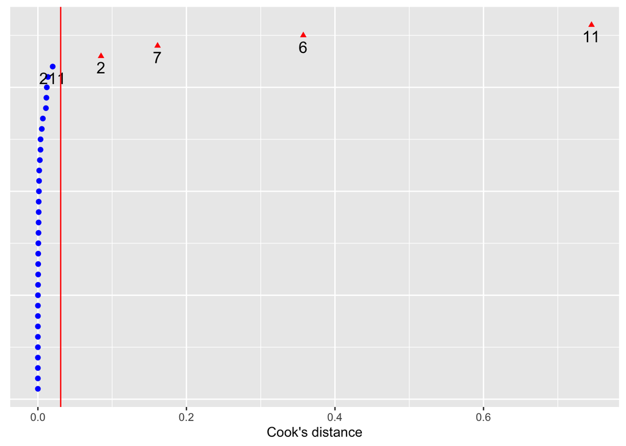

```r
dotplot_diag(x = cooks1, cutoff = "internal", name = "cooks.distance",  index=goals.baseline.data$subj) + ylab("Cook's distance") + xlab("subjID")
```

```r
excluded.subs <- c("2", "7", "6", "11")

goals.b1.cooks <- lmer(data = goals.baseline.data %>%
                         filter(!subj %in% excluded.subs),
                       formula = look_pref ~ 1 + ageday + (1|condition))

summary(goals.b1.cooks)
```

```
# Linear mixed model fit by REML. t-tests use Satterthwaite's method [
# lmerModLmerTest]
# Formula: look_pref ~ 1 + ageday + (1 | condition)
#    Data: goals.baseline.data %>% filter(!subj %in% excluded.subs)
#
# REML criterion at convergence: 239.2
#
# Scaled residuals:
#     Min      1Q  Median      3Q     Max
# -1.6626 -0.5931  0.0995  0.4841  2.8202
#
# Random effects:
#  Groups    Name        Variance Std.Dev.
#  condition (Intercept) 202      14.2
#  Residual              106      10.3
# Number of obs: 32, groups:  condition, 2
#
# Fixed effects:
#             Estimate Std. Error     df t value Pr(>|t|)
# (Intercept)   44.720     27.063 21.547    1.65     0.11
# ageday        -0.355      0.236 29.073   -1.51     0.14
#
# Correlation of Fixed Effects:
#        (Intr)
# ageday -0.925
```

```r
goals.baseline.cooks <- cbind(
  gen.beta(effectsize::standardize(goals.b1.cooks)),
  gen.m(goals.b1.cooks),
  gen.ci(goals.b1.cooks)[3:4,]
)
```

```
# Computing profile confidence intervals ...
```

```
# Warning in nextpar(mat, cc, i, delta, lowcut, upcut): unexpected decrease in
# profile: using minstep
```

```
# Warning in profile.merMod(object, which = parm, signames = oldNames, ...): non-
# monotonic profile for (Intercept)
```

```
# Warning in confint.thpr(pp, level = level, zeta = zeta): bad spline fit for
# (Intercept): falling back to linear interpolation
```

For standard versions of the goals task, we found differential looking between the expected and unexpected events, Mean_diff = 3.918 seconds, [-0.931,-0.081], ß=-0.318, B=-0.503, SE=0.214, p=0.025, two-tailed. However, this was driven by 4 influential observations - without these 4 observations, there was no longer a reliable looking preference, [-0.815,0.126], ß=-0.21, B=-0.355, SE=0.236, p=0.143, two-tailed.

### Intervention Analysis

```r
goals.m1 <- lmer(data = goals,
     formula = look_pref ~ training_yesno  + action_consequence + location_object_goal_ambiguous + agent + bothobjects_present_visible_fam + ageday + (1|condition) + (1|experiment) + (1|paper),
     control = lmerControl(optimizer="Nelder_Mead"))
```

```
# boundary (singular) fit: see ?isSingular
```

```r
summary(goals.m1)
```

```
# Linear mixed model fit by REML. t-tests use Satterthwaite's method [
# lmerModLmerTest]
# Formula:
# look_pref ~ training_yesno + action_consequence + location_object_goal_ambiguous +
#     agent + bothobjects_present_visible_fam + ageday + (1 | condition) +
#     (1 | experiment) + (1 | paper)
#    Data: goals
# Control: lmerControl(optimizer = "Nelder_Mead")
#
# REML criterion at convergence: 2842
#
# Scaled residuals:
#    Min     1Q Median     3Q    Max
# -4.049 -0.458 -0.028  0.416  2.921
#
# Random effects:
#  Groups     Name        Variance Std.Dev.
#  condition  (Intercept)  19.6     4.43
#  paper      (Intercept)   0.0     0.00
#  experiment (Intercept)   0.0     0.00
#  Residual               153.4    12.39
# Number of obs: 362, groups:  condition, 13; paper, 6; experiment, 2
#
# Fixed effects:
#                                  Estimate Std. Error       df t value Pr(>|t|)
# (Intercept)                       10.3237     6.2887  96.2681    1.64    0.104
# training_yesno1                   -1.9519     2.4419   4.8329   -0.80    0.462
# action_consequence1                2.8811     2.4462   7.9680    1.18    0.273
# location_object_goal_ambiguous1    5.1289     2.4944   8.5843    2.06    0.071
# agent1                            -5.4390     2.9960   6.3026   -1.82    0.117
# agent2                             6.4666     2.7646  19.3741    2.34    0.030
# bothobjects_present_visible_fam1  -5.3013     2.0586  15.0765   -2.58    0.021
# ageday                            -0.0733     0.0531 352.2521   -1.38    0.168
#
# (Intercept)
# training_yesno1
# action_consequence1
# location_object_goal_ambiguous1  .
# agent1
# agent2                           *
# bothobjects_present_visible_fam1 *
# ageday
# ---
# Signif. codes:  0 '***' 0.001 '**' 0.01 '*' 0.05 '.' 0.1 ' ' 1
#
# Correlation of Fixed Effects:
#             (Intr) trnn_1 actn_1 lc___1 agent1 agent2 bt___1
# tranng_ysn1 -0.295
# actn_cnsqn1 -0.246  0.002
# lctn_bjc__1  0.067  0.002  0.482
# agent1       0.011  0.547 -0.169  0.111
# agent2      -0.013 -0.297  0.024 -0.170 -0.796
# bthbjct___1  0.119  0.002 -0.245 -0.170  0.387 -0.563
# ageday      -0.875  0.043  0.053  0.038 -0.042  0.017  0.057
# convergence code: 0
# boundary (singular) fit: see ?isSingular
```

```r
goals %>%
  select(paper, experiment, condition, training_yesno, object_diff_size_huge,action_consequence,location_object_goal_ambiguous,agent,bothobjects_present_visible_fam) %>%
  distinct() %>%
  View()

# originally pre-registered model was rank deficient, needed to drop 2 variables
# dropped action_causal because it is redundant with action_consequence (i.e. there are no non-causal actions that are state changes)
# dropped object_diff_size_huge also because it is almost completely redundant with agent (i.e. all studies with a full human agent also are "yes" for "object_diff_size_huge")

# aa <- allFit(goals.m1)

summary(goals.m1)
```

```
# Linear mixed model fit by REML. t-tests use Satterthwaite's method [
# lmerModLmerTest]
# Formula:
# look_pref ~ training_yesno + action_consequence + location_object_goal_ambiguous +
#     agent + bothobjects_present_visible_fam + ageday + (1 | condition) +
#     (1 | experiment) + (1 | paper)
#    Data: goals
# Control: lmerControl(optimizer = "Nelder_Mead")
#
# REML criterion at convergence: 2842
#
# Scaled residuals:
#    Min     1Q Median     3Q    Max
# -4.049 -0.458 -0.028  0.416  2.921
#
# Random effects:
#  Groups     Name        Variance Std.Dev.
#  condition  (Intercept)  19.6     4.43
#  paper      (Intercept)   0.0     0.00
#  experiment (Intercept)   0.0     0.00
#  Residual               153.4    12.39
# Number of obs: 362, groups:  condition, 13; paper, 6; experiment, 2
#
# Fixed effects:
#                                  Estimate Std. Error       df t value Pr(>|t|)
# (Intercept)                       10.3237     6.2887  96.2681    1.64    0.104
# training_yesno1                   -1.9519     2.4419   4.8329   -0.80    0.462
# action_consequence1                2.8811     2.4462   7.9680    1.18    0.273
# location_object_goal_ambiguous1    5.1289     2.4944   8.5843    2.06    0.071
# agent1                            -5.4390     2.9960   6.3026   -1.82    0.117
# agent2                             6.4666     2.7646  19.3741    2.34    0.030
# bothobjects_present_visible_fam1  -5.3013     2.0586  15.0765   -2.58    0.021
# ageday                            -0.0733     0.0531 352.2521   -1.38    0.168
#
# (Intercept)
# training_yesno1
# action_consequence1
# location_object_goal_ambiguous1  .
# agent1
# agent2                           *
# bothobjects_present_visible_fam1 *
# ageday
# ---
# Signif. codes:  0 '***' 0.001 '**' 0.01 '*' 0.05 '.' 0.1 ' ' 1
#
# Correlation of Fixed Effects:
#             (Intr) trnn_1 actn_1 lc___1 agent1 agent2 bt___1
# tranng_ysn1 -0.295
# actn_cnsqn1 -0.246  0.002
# lctn_bjc__1  0.067  0.002  0.482
# agent1       0.011  0.547 -0.169  0.111
# agent2      -0.013 -0.297  0.024 -0.170 -0.796
# bthbjct___1  0.119  0.002 -0.245 -0.170  0.387 -0.563
# ageday      -0.875  0.043  0.053  0.038 -0.042  0.017  0.057
# convergence code: 0
# boundary (singular) fit: see ?isSingular
```

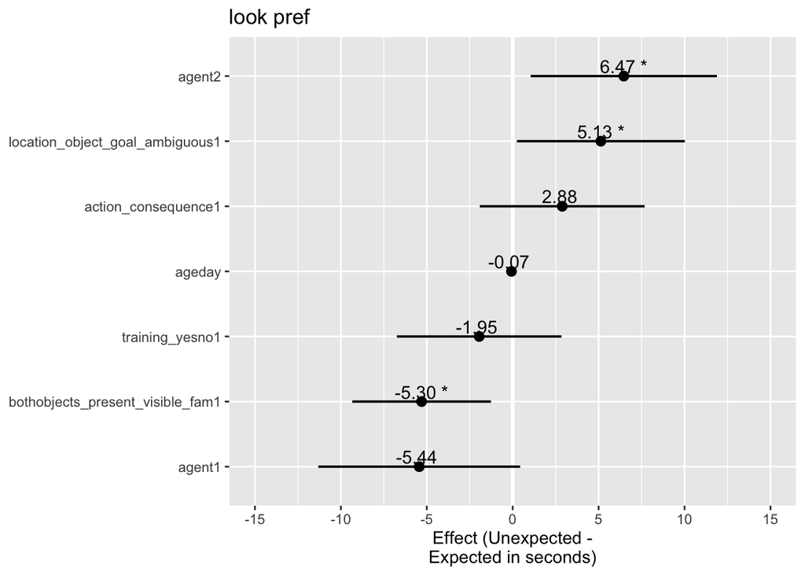

```r
sjPlot::plot_model(goals.m1,
                   type = "est",
                   colors = "bw",
                   sort.est=TRUE,
                   axis.title=c("Effect (Unexpected - Expected in seconds)"),
                   show.values=TRUE,
                   show.p=TRUE)
```

```r
sjPlot:: tab_model(goals.m1)
```

|  | look pref |  |  |
| --- | --- | --- | --- |
| Predictors | Estimates | CI | p |
| (Intercept) | 10.32 | -2.00 – 22.65 | 0.101 |
| training_yesno1 | -1.95 | -6.74 – 2.83 | 0.424 |
| action_consequence1 | 2.88 | -1.91 – 7.68 | 0.239 |
| location_object_goal_ambiguous1 | 5.13 | 0.24 – 10.02 | **0.040** |
| agent1 | -5.44 | -11.31 – 0.43 | 0.069 |
| agent2 | 6.47 | 1.05 – 11.89 | **0.019** |
| bothobjects_present_visible_fam1 | -5.30 | -9.34 – -1.27 | **0.010** |
| ageday | -0.07 | -0.18 – 0.03 | 0.168 |
| Random Effects |  |  |  |
| σ<sup>2</sup> | 153.43 |  |  |
| τ<sub>00</sub> <sub>condition</sub> | 19.60 |  |  |
| τ<sub>00</sub> <sub>paper</sub> | 0.00 |  |  |
| τ<sub>00</sub> <sub>experiment</sub> | 0.00 |  |  |
| N <sub>condition</sub> | 13 |  |  |
| N <sub>experiment</sub> | 2 |  |  |
| N <sub>paper</sub> | 6 |  |  |
| Observations | 362 |  |  |
| Marginal R<sup>2</sup> / Conditional R<sup>2</sup> | 0.104 / NA |  |  |

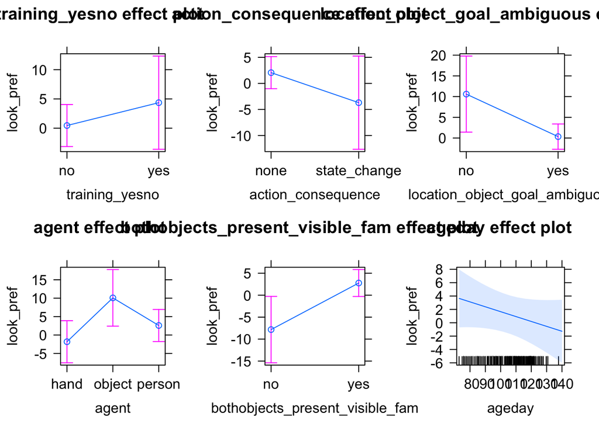

```r
plot(allEffects(goals.m1))
```

```r
goals.interventions<- cbind(
  gen.beta(effectsize::standardize(goals.m1)),
  gen.m(goals.m1),
  gen.ci(goals.m1)[4:11,]
)
```

```
# boundary (singular) fit: see ?isSingular
```

```
# Computing profile confidence intervals ...
```

[output not shown]

```
# Warning in profile.merMod(object, which = parm, signames = oldNames, ...): non-
# monotonic profile for (Intercept)
```

```
# Warning in nextpar(mat, cc, i, delta, lowcut, upcut): unexpected decrease in
# profile: using minstep
```

```
# Warning in profile.merMod(object, which = parm, signames = oldNames, ...): non-
# monotonic profile for agent2
```

```
# Warning in confint.thpr(pp, level = level, zeta = zeta): bad spline fit for
# (Intercept): falling back to linear interpolation
```

```
# Warning in confint.thpr(pp, level = level, zeta = zeta): bad spline fit for
# agent2: falling back to linear interpolation
```

```r
cooks1 <- cooks.distance(goals.m1, group = "subj")
```

```
# Warning in cooks.distance.lmerMod(goals.m1, group = "subj"): group is not a
# valid argument for this function. As of version 0.4.0, group has been replaced
# by level.
```

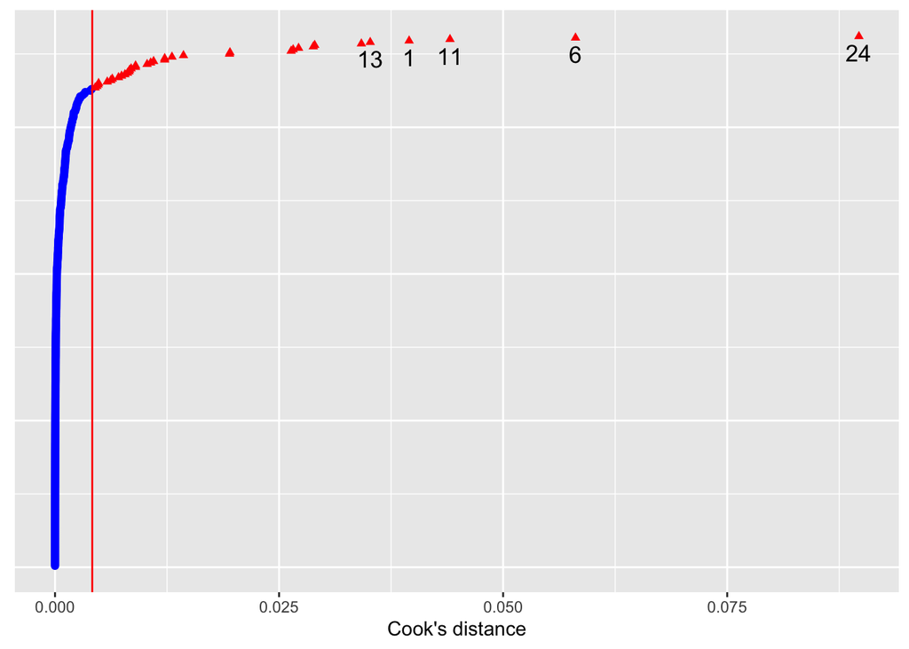

```r
dotplot_diag(x = cooks1, cutoff = "internal", name = "cooks.distance",  index=goals$subj) + ylab("Cook's distance") + xlab("subjID")
```

```r
goals.cooks <- goals[which(cooks1 <= 4/362),]

goals.m1.cooks <- lmer(data = goals.cooks,
     formula = look_pref ~ training_yesno  + action_consequence + location_object_goal_ambiguous + agent + bothobjects_present_visible_fam + ageday + (1|condition) + (1|experiment) + (1|paper),
     control = lmerControl(optimizer="Nelder_Mead"))
```

```
# boundary (singular) fit: see ?isSingular
```

```r
fixef(goals.m1.cooks)
```

```
#                      (Intercept)                  training_yesno1
#                          6.06716                         -1.83931
#              action_consequence1  location_object_goal_ambiguous1
#                          2.33221                          5.15730
#                           agent1                           agent2
#                         -4.46125                          5.60015
# bothobjects_present_visible_fam1                           ageday
#                         -3.07025                         -0.01669
```

```r
fixef(goals.m1.cooks,add.dropped=TRUE)
```

```
#                      (Intercept)                  training_yesno1
#                          6.06716                         -1.83931
#              action_consequence1  location_object_goal_ambiguous1
#                          2.33221                          5.15730
#                           agent1                           agent2
#                         -4.46125                          5.60015
# bothobjects_present_visible_fam1                           ageday
#                         -3.07025                         -0.01669
```

```r
summary(goals.m1.cooks)
```

```
# Linear mixed model fit by REML. t-tests use Satterthwaite's method [
# lmerModLmerTest]
# Formula:
# look_pref ~ training_yesno + action_consequence + location_object_goal_ambiguous +
#     agent + bothobjects_present_visible_fam + ageday + (1 | condition) +
#     (1 | experiment) + (1 | paper)
#    Data: goals.cooks
# Control: lmerControl(optimizer = "Nelder_Mead")
#
# REML criterion at convergence: 2595
#
# Scaled residuals:
#    Min     1Q Median     3Q    Max
# -3.484 -0.459 -0.042  0.468  3.371
#
# Random effects:
#  Groups     Name        Variance Std.Dev.
#  condition  (Intercept)  13.3     3.64
#  paper      (Intercept)   0.0     0.00
#  experiment (Intercept)   0.0     0.00
#  Residual               110.0    10.49
# Number of obs: 345, groups:  condition, 13; paper, 6; experiment, 2
#
# Fixed effects:
#                                  Estimate Std. Error       df t value Pr(>|t|)
# (Intercept)                        6.0672     5.4877 109.6470    1.11    0.271
# training_yesno1                   -1.8393     2.0190   4.7758   -0.91    0.406
# action_consequence1                2.3322     2.0883   8.2716    1.12    0.295
# location_object_goal_ambiguous1    5.1573     2.2202   9.8410    2.32    0.043
# agent1                            -4.4613     2.5736   6.7760   -1.73    0.128
# agent2                             5.6002     2.6245  23.8723    2.13    0.043
# bothobjects_present_visible_fam1  -3.0702     1.8673  12.4200   -1.64    0.125
# ageday                            -0.0167     0.0465 336.0909   -0.36    0.720
#
# (Intercept)
# training_yesno1
# action_consequence1
# location_object_goal_ambiguous1  *
# agent1
# agent2                           *
# bothobjects_present_visible_fam1
# ageday
# ---
# Signif. codes:  0 '***' 0.001 '**' 0.01 '*' 0.05 '.' 0.1 ' ' 1
#
# Correlation of Fixed Effects:
#             (Intr) trnn_1 actn_1 lc___1 agent1 agent2 bt___1
# tranng_ysn1 -0.284
# actn_cnsqn1 -0.226  0.002
# lctn_bjc__1  0.067  0.002  0.519
# agent1      -0.005  0.527 -0.154  0.123
# agent2       0.027 -0.260 -0.007 -0.201 -0.796
# bthbjct___1  0.114  0.003 -0.247 -0.151  0.411 -0.545
# ageday      -0.880  0.046  0.048  0.034 -0.023 -0.014  0.073
# convergence code: 0
# boundary (singular) fit: see ?isSingular
```

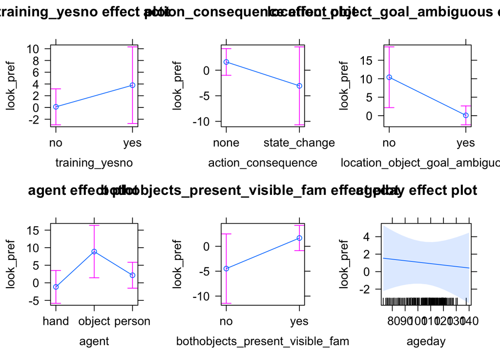

```r
plot(allEffects(goals.m1.cooks))
```

```r
goals.interventions.cooks<- cbind(
  gen.beta(effectsize::standardize(goals.m1.cooks)),
  gen.m(goals.m1.cooks),
  gen.ci(goals.m1.cooks)[4:11,]
)
```

```
# boundary (singular) fit: see ?isSingular
# Computing profile confidence intervals ...
```

We note that the analysis we reported deviates from our pre-registration plan. In that plan, we included 8 fixed effects, including a fixed effect for age in days, one picking out a control condition, and 6 others. However, 2 of these fixed effects were either completely or partially redundant with other predictors in the model, which caused a rank deficiency issue. Thus, we dropped these two fixed effects from the model. We report this new model below.